# Quarto Fundamentals

## 3.3 Code Chunk Options

In Quarto code chunk options are set using the `#|` (hashpipe) syntax at the top of a chunk. These control how each chunk behaves during rendering. Below are some of the most common.

### 3.3.1 Adding a Label

Labels help with navigation and cross-referencing. You can cross-reference a code chunk by using the `@label-name` syntaxt. If you prefix the label with `fig-` or `tbl-` Quarto will enable automatic numbering of figures and plots when cross-referencing (e.g., Table 1, Table 2, etc.):

````markdown
```{r}
#| label: fig-example-plot
```
````

### 3.3.2 Controlling Code Display with `echo`

The `echo` option controls whether the **source code** appears in the rendered document.

````markdown
```{r}
#| label: echo-demo
#| echo: false

# This code runs, but will not appear in the rendered document
hidden_result <- 42 * 2
hidden_result
```
````

The above code chunk is included in an executable chunk below.

```
[1] 84
```

The result above (84) was produced by code, but the code itself is hidden because `echo: false` was set.

### 3.3.3 Controlling Code Execution with `eval`

The `eval` option controls whether the code **runs** at all:

```r
# This code is displayed but does NOT execute
this_would_cause_an_error <- nonexistent_function()
```

The chunk above is displayed but was never executed, so no error occurs (which would ordinarily prevent rendering).

### 3.3.4 Controlling Output Display with `include`

The `include` option controls whether **anything** from the chunk (code or results) appears in the rendered document. When `include: false`, the code still runs, but nothing is shown:

````markdown
```{r}
#| label: include-demo
#| include: false

# This runs silently --- useful for setup code
library(ggplot2)
sample_data <- mtcars
sample_data
```
````

This code is included below, but no code or output are displayed.

We can confirm that the code was run by using the inline snippet, `32`: 32.

### 3.3.5 Setting Global Options in the YAML Header

Instead of setting options chunk-by-chunk, you can set defaults for the entire document in the YAML header:

```yaml
---
title: "My Report"
execute:
  echo: true
  warning: false
  message: false
---
```

This hides warnings and messages throughout the document while still displaying code. Individual chunks can override these defaults.

## 3.4 Tables, Figures, and References

Let’s create some example tables and figures using the built-in `mtcars` dataset.

### 3.4.1 Table Display

Table 1: Summary Statistics of MPG by Number of Cylinders

```r
# Create a summary table using base R
mtcars_summary <- mtcars |>
  group_by(cyl) |>
  summarize(
    across(
      c(mpg, hp, wt),
      \(x) round(mean(x), 1)
    )
  ) |>
  rename(
    "Cylinders" = cyl,
    "Avg MPG" = mpg,
    "Avg HP" = hp,
    "Avg Weight (1000 lbs)" = wt
  )

mtcars_summary
```

```
# A tibble: 3 × 4
  Cylinders `Avg MPG` `Avg HP` `Avg Weight (1000 lbs)`
      <dbl>     <dbl>    <dbl>                   <dbl>
1         4      26.7     82.6                     2.3
2         6      19.7    122.                      3.1
3         8      15.1    209.                      4
```

As shown in Table 1, vehicles with fewer cylinders tend to have higher fuel efficiency.

You can also format tables using dedicated packages for more control:

- `knitr::kable()` — simple, reliable table formatting
- `kableExtra` — extends kable with styling options
- `flextable` — flexible tables that work across output formats
- `gt` — a grammar of tables, great for publication-quality output

### 3.4.2 Figure Display

You can control figure appearance using chunk options for dimensions, alignment, captions, and alt text:

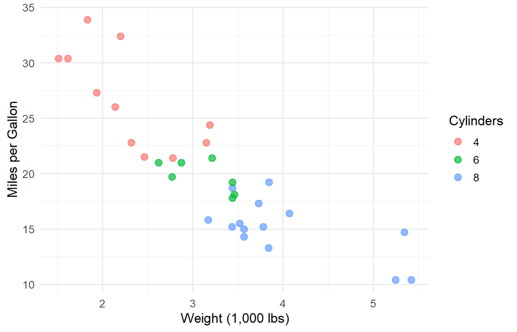

Figure 1: Relationship Between Vehicle Weight and Fuel Efficiency

```r
ggplot(mtcars, aes(x = wt, y = mpg, color = factor(cyl))) +
  geom_point(size = 3, alpha = 0.7) +
  labs(
    x = "Weight (1,000 lbs)",
    y = "Miles per Gallon",
    color = "Cylinders"
  ) +
  theme_minimal(base_size = 13)
```

As shown in Figure 1, there is a clear negative relationship between vehicle weight and fuel efficiency. Note how Quarto automatically numbers the figure based on its order in the document.

#### 3.4.2.1 Multiple Figures in One Chunk

When a code chunk produces multiple figures, you can control the layout using chunk settings like `fig-subcap` and `layout-ncol`:

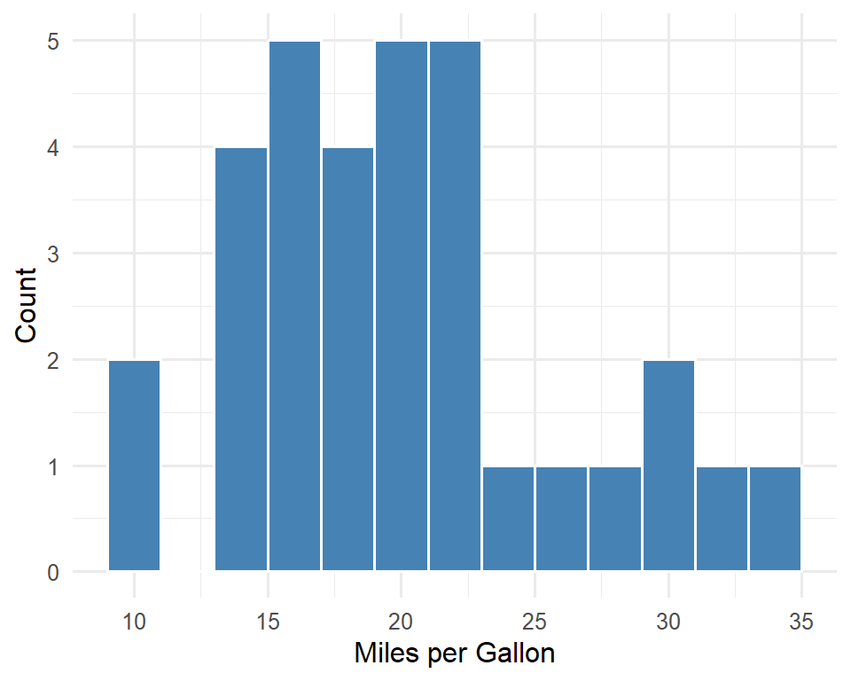

(a) Distribution of MPG

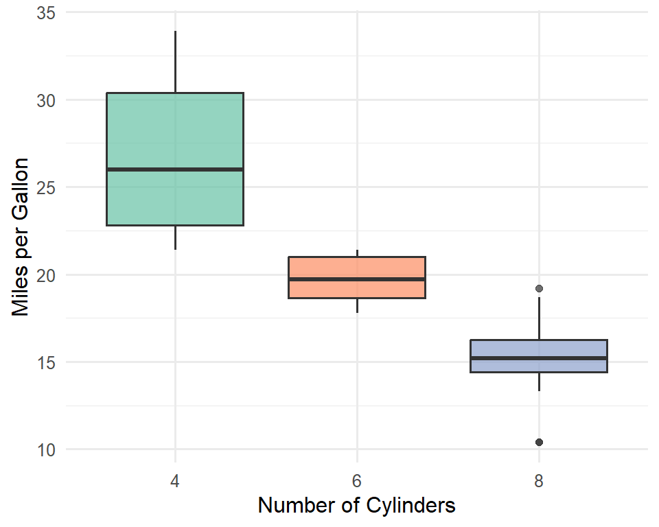

(b) MPG by Cylinder Count

Figure 2: Fuel Efficiency Distributions

```r
# Panel (a): Histogram
ggplot(mtcars, aes(x = mpg)) +
  geom_histogram(binwidth = 2, fill = "steelblue", color = "white") +
  labs(x = "Miles per Gallon", y = "Count") +
  theme_minimal(base_size = 12)

# Panel (b): Boxplot
ggplot(mtcars, aes(x = factor(cyl), y = mpg, fill = factor(cyl))) +
  geom_boxplot(alpha = 0.7, show.legend = FALSE) +
  labs(x = "Number of Cylinders", y = "Miles per Gallon") +
  scale_fill_brewer(palette = "Set2") +
  theme_minimal(base_size = 12)
```

Figure 2 shows two views of the MPG distribution: Figure 2 (a) presents the overall distribution, while Figure 2 (b) breaks it down by cylinder count.

### 3.4.3 Cross-References

For both figures and tables, you can create in-text references using `@label`. Quarto will automatically generate the correct numbering:

- `@fig-mpg-scatter` renders as a clickable link like “Figure 1”
- `@tbl-mtcars-summary` renders as “Table 1”

The labels must begin with the `fig-` or `tbl-` prefix, and the chunk must include a `fig-cap` or `tbl-cap` for cross-referencing to work.

## 3.5 Footnotes

There are several ways to add footnotes in Quarto.

**Numbered footnotes** use a reference marker in the text and define the content elsewhere:

```markdown
This is a statement that needs a footnote[^1].

[^1]: This is the footnote content.
```

This is a statement that needs a footnote[^1].

**Named footnotes** use a descriptive label instead of a number, which can be easier to manage in longer documents:

```markdown
Quarto supports many output formats[^formats].

[^formats]: Including HTML, PDF, Word, revealjs slides, and more.
```

Quarto supports many output formats[^2].

**Inline footnotes** let you write the content directly in the text without a separate definition:

```markdown
This is convenient for short notes^[Like this one, which does not require a separate definition.].
```

This is convenient for short notes[^3].

# 4 More Features and Formats

## 4.1 Caching Results

For documents with long-running computations, you can **cache** results so that chunks only re-execute when their code changes.

Add caching to a single chunk:

````markdown
```{r}
#| cache: true

# This long computation will only run once
result <- some_slow_function(data)
```
````

Or enable caching for the entire document in the YAML header:

```yaml
execute:
  cache: true
```

When caching is enabled, Quarto creates a folder named `document-name_cache` containing the stored results. If the code in a cached chunk changes, that chunk (and any chunks that depend on it) will re-execute.

**Caching Caveats**

Caching can sometimes cause unexpected behavior if chunks depend on external data that has changed or on objects modified in other chunks. If you encounter strange results, try deleting the cache folder and re-rendering.

## 4.2 Callout Blocks

Callout blocks are a great way to draw attention to important information. Quarto supports five types:

**Note**

Use for additional context or supplementary information.

**Warning**

Use to flag potential problems or common mistakes.

**Important**

Use for critical information the reader must not miss.

**Tip**

Use for helpful suggestions and best practices.

**Caution**

Use to warn about actions that could cause issues.

The syntax for creating a callout is:

```markdown
::: {.callout-note}
## Optional Title
Content of the callout goes here.
:::
```

You can also add attributes. For example, a **collapsible** callout:

```markdown
::: {.callout-tip collapse="true"}
## Click to Expand
This content is hidden by default.
:::
```

**Click to Expand**

This content is hidden by default. It appears when the reader clicks the callout header.

You can also change the appearance to a simpler style:

```markdown
::: {.callout-note appearance="simple"}
A simpler, more understated callout style.
:::
```

## 4.3 Bibliography and Citation Integration

Quarto has built-in support for citations and bibliographies, making it an excellent tool for academic and research writing.

**Step 1**: Create or export a bibliography file (e.g., `references.bib`) from a reference manager like **Zotero**, **Mendeley**, or **EndNote**. A `.bib` file entry looks like this:

```
@article{wickham2014,
  title={Tidy Data},
  author={Wickham, Hadley},
  journal={Journal of Statistical Software},
  volume={59},
  number={10},
  year={2014}
}
```

**Step 2**: Reference the bibliography file in your YAML header, and optionally specify a citation style:

```yaml
---
title: "My Research Paper"
bibliography: references.bib
csl: apa.csl
---
```

Citation style files (`.csl`) for virtually any journal or style guide (APA, Chicago, MLA, etc.) can be downloaded from the [Zotero Style Repository](https://www.zotero.org/styles).

**Step 3**: Cite sources in your text using the `[@key]` syntax:

```markdown
Tidy data principles have transformed data analysis workflows [@wickham2014].
```

Quarto will automatically generate a formatted **References** section at the end of your document.

## 4.4 Dashboards, Websites, Books, and More!

Quarto can do much more than single-page reports. The same core skills you have learned today apply to a wide range of output types:

- **Presentations**: Create slides using `format: revealjs` for HTML presentations or `format: beamer` for PDF slides
- **Websites**: Build multi-page websites with navigation, hosted on GitHub Pages or other platforms
- **Books**: Write multi-chapter books with cross-references, indexing, and multiple output formats
- **Dashboards**: Create interactive dashboards using `format: dashboard` with layouts and value boxes

These all use the same Markdown syntax, code chunks, and YAML configuration you have practiced today.

**Learn More**

Visit the [Quarto documentation](https://quarto.org/docs/guide/) for guides and examples of all these formats.

## Footnotes

[^1]: This is the footnote content.
[^2]: Including HTML, PDF, Word, revealjs slides, and more.
[^3]: Like this one, which does not require a separate definition.